# Looping

Naomi Tague

January, 2025

# A more complex example of looping in R

### Note, I edited this RMD with the required changes for HW #4

Lets **scale** up from a single car to a group of cars on a highway and use our **autopower** function to estimate a distribution of power

What might vary?

# Our highway

4 car types

Mean highway speed is 80 km/hr

```r
source("../ESM262_HW4/autopower.R")
# generate a structure to store info on our possible cars
possible_cars = data.frame(name = c("A","B","C","D"),mass=c(10000,65000,38000,5000), area = c(22,30,22,10))

# first look at how results vary for mean speed say 80km/hr
# do conversion from km to meters per second
speed_base = 80 * 0.28

# because I have one mass and area for each car and only 1 speed
# I can estimate power for each car type
# add to the data structure
possible_cars$power = autopower(V=speed_base, A = possible_cars$area, m=possible_cars$mass)

head(possible_cars)
```

```
##   name  mass area     power
## 1    A 10000   22  77436.12
## 2    B 65000   30 274724.89
## 3    C 38000   22 169634.52
## 4    D  5000   10  36694.96
```

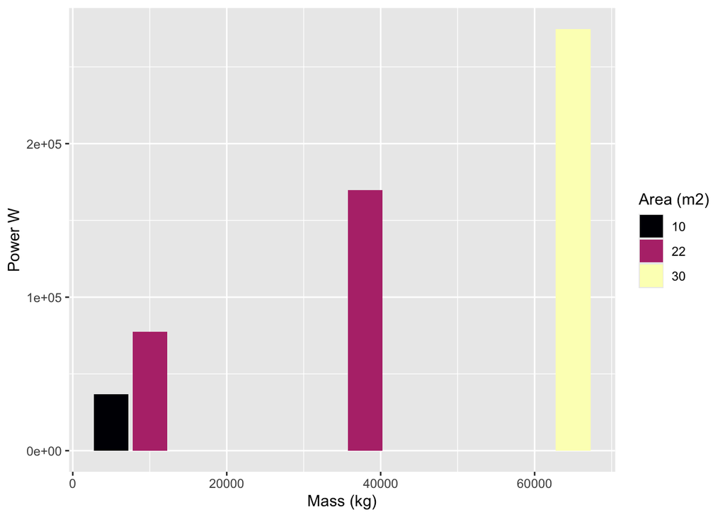

```r
# show results
ggplot(possible_cars, aes(x=mass, y=power, fill=as.factor(area)))+geom_col()+labs(y="Power W", x="Mass (kg)", fill="Area (m2)")+
  scale_fill_viridis(discrete=TRUE,option = "magma")
```

# Building a highway

What could be the total power consumed if there are 200 cars on this highway each hour, they are travelling at a range of speeds - mean is 80km/hr and speeds tend to be log-normally distributed)

How would the total power consumed vary by car So if all cars are car A; OR all cars are car B; OR all cars are car C; OR all cars are car D

We will use *sample* here to generate speeds for our 200 cars and look at different ways to repeat power calculation for different cars

- repeating by hand
- *pmap* for repetition - a efficient way of looping in R
- *for* for repetition - a more standard way of looping available in many langugaes